# Course Project

Andrew Samodurov

23 October 2015 г.

## Course Project - Predicting the manner of doing exercises

## Background

Using devices such as Jawbone Up, Nike FuelBand, and Fitbit it is now possible to collect a large amount of data about personal activity relatively inexpensively. These type of devices are part of the quantified self movement – a group of enthusiasts who take measurements about themselves regularly to improve their health, to find patterns in their behavior, or because they are tech geeks. One thing that people regularly do is quantify how much of a particular activity they do, but they rarely quantify how well they do it. The goal is to use data from accelerometers on the belt, forearm, arm, and dumbell of 6 participants. They were asked to perform barbell lifts correctly and incorrectly in 5 different ways. http://groupware.les.inf.puc-rio.br/har

## Data

The training data for this project are available here:

https://d396qusza40orc.cloudfront.net/predmachlearn/pml-training.csv

The test data are available here:

https://d396qusza40orc.cloudfront.net/predmachlearn/pml-testing.csv

### Libraries

```r
library(AppliedPredictiveModeling)
library(caret)
library(rattle)
```

```r
library(rpart.plot)
library(randomForest)
```

### Downloading Train and Test datasets

To make this research reproducible, it make sence to download data from the source site:

```r
train <- read.csv("https://d396qusza40orc.cloudfront.net/predmachlearn/pml-training.csv", na.strings=c("NA", ""), header = T)

dim(train)
```

```
## [1] 19622   160
```

```r
test <- read.csv("https://d396qusza40orc.cloudfront.net/predmachlearn/pml-testing.csv", na.strings=c("NA", ""), header = T)
dim(test)
```

```
## [1]  20 160
```

So we have two datasets with equvivalent numbers of colomns(variables). Let`s do some manipulating with Train data to make it tidy:

### Summarize number of NA values

First we calculate the number of NA values in Train dataset to decide which variables we can neglect.

```r
notNA_length <- as.vector(apply(train, 2, function(x) {length(which(!is.na(x)))}))
summary(notNA_length)
```

```
##    Min. 1st Qu.  Median    Mean 3rd Qu.    Max.
##     406     406     406    7612   19620   19620
```

```r
col_to_drop <- notNA_length < mean(notNA_length)
```

As we can se, it is possible to drop `100` colomns where number of NA`s is too big. Also we can drop the first seven colomn - they are not usable for learning.

```r
train <- train[, !col_to_drop]
train <- train[, -c(1:7)]
dim(train)
```

```
## [1] 19622    53
```

```r
test <- test[, !col_to_drop]
test <- test[, -c(1:7)]
dim(test)
```

```
## [1] 20 53
```

```r
names(train)
```

```
##  [1] "roll_belt"            "pitch_belt"           "yaw_belt"
##  [4] "total_accel_belt"     "gyros_belt_x"         "gyros_belt_y"
##  [7] "gyros_belt_z"         "accel_belt_x"         "accel_belt_y"
## [10] "accel_belt_z"         "magnet_belt_x"        "magnet_belt_y"
## [13] "magnet_belt_z"        "roll_arm"             "pitch_arm"
## [16] "yaw_arm"              "total_accel_arm"      "gyros_arm_x"
## [19] "gyros_arm_y"          "gyros_arm_z"          "accel_arm_x"
## [22] "accel_arm_y"          "accel_arm_z"          "magnet_arm_x"
## [25] "magnet_arm_y"         "magnet_arm_z"         "roll_dumbbell"
## [28] "pitch_dumbbell"       "yaw_dumbbell"         "total_accel_dumbbell"
## [31] "gyros_dumbbell_x"     "gyros_dumbbell_y"     "gyros_dumbbell_z"
## [34] "accel_dumbbell_x"     "accel_dumbbell_y"     "accel_dumbbell_z"
## [37] "magnet_dumbbell_x"    "magnet_dumbbell_y"    "magnet_dumbbell_z"
## [40] "roll_forearm"         "pitch_forearm"        "yaw_forearm"
## [43] "total_accel_forearm"  "gyros_forearm_x"      "gyros_forearm_y"
## [46] "gyros_forearm_z"      "accel_forearm_x"      "accel_forearm_y"
## [49] "accel_forearm_z"      "magnet_forearm_x"     "magnet_forearm_y"
## [52] "magnet_forearm_z"     "classe"
```

Therefore, we have 52 covariates to make a prediction.

### Checking for covariates

Some of covariates may have near zero variablility, so we need to check that.

```r
nzv <- nearZeroVar(train, saveMetrics = T)
sum(nzv$zeroVar)
```

```
## [1] 0
```

```r
sum(nzv$nzv)
```

```
## [1] 0
```

As we can see, there are no such variables.

### Partition

Now we will make a partition to split the data into train and test sets:

```r
Train <- createDataPartition(y=train$classe, p=0.6, list=FALSE)
Training <- train[Train, ]
Testing <- train[-Train, ]
dim(Training); dim(Testing)
```

```
## [1] 11776    53
```

```
## [1] 7846   53
```

60% of initial data will be in a Training set and other 40% will helps us to calculate an accuracy.

### PCA

First, let`s doing some Principal Component Analysis.

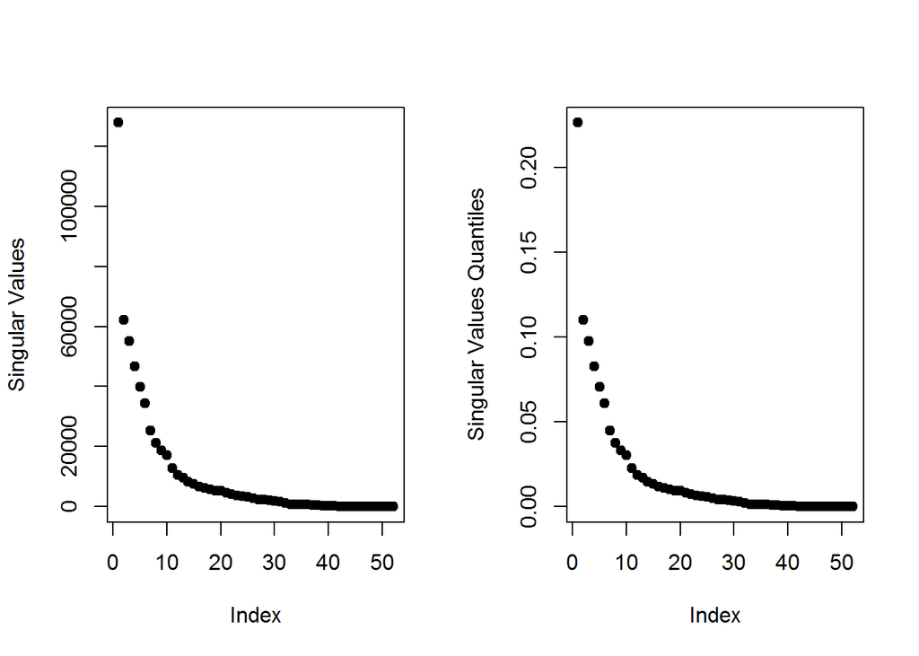

```r
svd1 <- svd(Training[, -53])
par(mfrow = c(1, 2))
plot(svd1$d, pch = 19, ylab = "Singular Values")
plot(svd1$d / sum(svd1$d), pch = 19, ylab = "Singular Values Quantiles")
```

```r
par(mfrow = c(1, 1))
sdd <- svd1$d / sum(svd1$d)
sum(sdd[-c(1:20)])
```

```
## [1] 0.06783903
```

As we can see, first 20 principal components cover more then 93% of variation.

## Fitting Models

### Decision Tree

First, we will try to make a simple prediction model - decision tree.

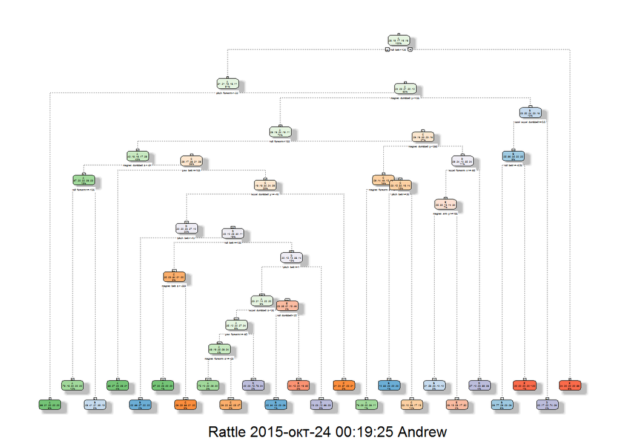

```r
modelFit1 <- rpart(Training$classe ~ ., data = Training, method="class")
fancyRpartPlot(modelFit1)
```

```r
prediction1 <- predict(modelFit1, Testing, type = "class")
confusionMatrix(prediction1, Testing$classe)
```

```
## Confusion Matrix and Statistics
##
##           Reference
## Prediction    A    B    C    D    E
##          A 1954  252   29   70   19
##          B   83  941  123  107  132
##          C   59  147 1076  208  154
##          D   73  102   96  804   66
##          E   63   76   44   97 1071
##
## Overall Statistics
##
##                Accuracy : 0.7451
##                  95% CI : (0.7353, 0.7547)
##     No Information Rate : 0.2845
##     P-Value [Acc > NIR] : < 2.2e-16
##
##                   Kappa : 0.6771
##  Mcnemar's Test P-Value : < 2.2e-16
##
## Statistics by Class:
##
##                      Class: A Class: B Class: C Class: D Class: E
## Sensitivity            0.8754   0.6199   0.7865   0.6252   0.7427
## Specificity            0.9341   0.9297   0.9123   0.9486   0.9563
## Pos Pred Value         0.8408   0.6789   0.6545   0.7046   0.7927
## Neg Pred Value         0.9497   0.9107   0.9529   0.9281   0.9429
## Prevalence             0.2845   0.1935   0.1744   0.1639   0.1838
## Detection Rate         0.2490   0.1199   0.1371   0.1025   0.1365
## Detection Prevalence   0.2962   0.1767   0.2095   0.1454   0.1722
## Balanced Accuracy      0.9048   0.7748   0.8494   0.7869   0.8495
```

### Random Forest

```r
modelFit2 <- randomForest(classe ~ ., data = Training)
prediction2 <- predict(modelFit2, Testing, type = "class")
confusionMatrix(prediction2, Testing$classe)
```

```
## Confusion Matrix and Statistics
##
##           Reference
## Prediction    A    B    C    D    E
##          A 2225   10    0    0    0
##          B    6 1506   10    0    0
##          C    0    2 1356   19    4
##          D    0    0    2 1264    5
##          E    1    0    0    3 1433
##
## Overall Statistics
##
##                Accuracy : 0.9921
##                  95% CI : (0.9899, 0.9939)
##     No Information Rate : 0.2845
##     P-Value [Acc > NIR] : < 2.2e-16
##
##                   Kappa : 0.99
##  Mcnemar's Test P-Value : NA
##
## Statistics by Class:
##
##                      Class: A Class: B Class: C Class: D Class: E
## Sensitivity            0.9969   0.9921   0.9912   0.9829   0.9938
## Specificity            0.9982   0.9975   0.9961   0.9989   0.9994
## Pos Pred Value         0.9955   0.9895   0.9819   0.9945   0.9972
## Neg Pred Value         0.9988   0.9981   0.9981   0.9967   0.9986
## Prevalence             0.2845   0.1935   0.1744   0.1639   0.1838
## Detection Rate         0.2836   0.1919   0.1728   0.1611   0.1826
## Detection Prevalence   0.2849   0.1940   0.1760   0.1620   0.1832
## Balanced Accuracy      0.9975   0.9948   0.9937   0.9909   0.9966
```

The Accuracy of this method is much bigger, it`s almost 100%, so we will predict Classes for Test set using this model.

## Prediction

To predict a manner of doing exercise we will use the Random Forest classifier which shows the best accuracy.

```r
Prediction <- predict(modelFit2, test, type = "class")
```

To finish this course project we need to save results of predictin in text files:

```r
pml_write_files = function(x){
  n = length(x)
  for(i in 1:n){
    filename = paste0("problem_id_",i,".txt")
    write.table(x[i],file=filename,quote=FALSE,row.names=FALSE,col.names=FALSE)
  }
}
pml_write_files(Prediction)
```